# Velocity model v0.4.0: v0.3.1 re-inverted with the re-timed picks

v0.3.1 configuration re-inverted with the re-timed picks (D-B072/D-B075); no surface treatment, no D-B073 rule. Generated by workflow/10_tomography/b2_v040_analyse.py (branch tomo/v040-retimed). Same events, picks, weights, OBS S statics, P-4 rule, damping 200, smoothing and merge rules as v0.3.1; only the pick times differ (D-B072/D-B075). ridges_north was not rerun: it is out of the merge (D-B050).

## 1. Picks re-timed in the tomography

Unique B1b tomography picks: 754,710; re-timed 65,562 (8.7 %) on 59 stations (5061 on OBS); |correction| > 0.02 s: 33,976, > 0.05 s: 28,668, > 0.1 s: 25,426, > 0.3 s: 11,975; epoch class listed 31,538, found 36,567.

| region | phase | picks | retimed | retimed_pct | listed | found | stations_retimed | obs_retimed | gt_0.02s | gt_0.05s | gt_0.1s | gt_0.3s | median_abs_s | max_abs_s |
| --- | --- | --- | --- | --- | --- | --- | --- | --- | --- | --- | --- | --- | --- | --- |
| M0 | P | 118325 | 12426 | 10.5 | 7272 | 5586 | 57 | 284 | 7570 | 6581 | 5878 | 2808 | 0.0788 | 0.7696 |
| M0 | S | 110983 | 8943 | 8.06 | 5372 | 3841 | 55 | 329 | 5528 | 4863 | 4347 | 2000 | 0.0914 | 0.77 |
| M0 | all | 229308 | 21369 | 9.32 | 12644 | 9427 | 57 | 613 | 13098 | 11444 | 10225 | 4808 | 0.0896 | 0.77 |
| mendocino_gorda_c | P | 129060 | 313 | 0.24 | 0 | 313 | 3 | 312 | 0 | 0 | 0 | 0 | 0.0031 | 0.008 |
| mendocino_gorda_c | S | 138774 | 595 | 0.43 | 0 | 595 | 2 | 595 | 0 | 0 | 0 | 0 | 0.0031 | 0.0069 |
| mendocino_gorda_c | all | 267834 | 908 | 0.34 | 0 | 908 | 3 | 907 | 0 | 0 | 0 | 0 | 0.0031 | 0.008 |
| blanco | P | 41917 | 2064 | 4.92 | 0 | 2066 | 6 | 2064 | 0 | 0 | 0 | 0 | 0.0036 | 0.0095 |
| blanco | S | 43376 | 2066 | 4.76 | 0 | 2072 | 6 | 2066 | 0 | 0 | 0 | 0 | 0.0036 | 0.0095 |
| blanco | all | 85293 | 4130 | 4.84 | 0 | 4138 | 6 | 4130 | 0 | 0 | 0 | 0 | 0.0036 | 0.0095 |
| oregon | P | 63039 | 12404 | 19.68 | 7636 | 5201 | 31 | 0 | 7943 | 6816 | 6105 | 3207 | 0.0921 | 0.7696 |
| oregon | S | 59253 | 9711 | 16.39 | 6141 | 3889 | 30 | 0 | 6349 | 5489 | 4890 | 2402 | 0.1007 | 0.77 |
| oregon | all | 122292 | 22115 | 18.08 | 13777 | 9090 | 31 | 0 | 14292 | 12305 | 10995 | 5609 | 0.0995 | 0.77 |
| washington | P | 170098 | 29473 | 17.33 | 15179 | 15553 | 45 | 0 | 16370 | 13803 | 12239 | 5794 | 0.0313 | 0.5412 |
| washington | S | 164780 | 23643 | 14.35 | 12479 | 12120 | 44 | 0 | 13393 | 11346 | 10059 | 4560 | 0.04 | 0.5413 |
| washington | all | 334878 | 53116 | 15.86 | 27658 | 27673 | 45 | 0 | 29763 | 25149 | 22298 | 10354 | 0.039 | 0.5413 |

Stations with re-timed picks (per inversion, largest counts first; full table picks_retimed_by_station.csv):

| station | region | retimed | P | S | median_corr_s | max_abs_corr_s | class | picks_at_station |
| --- | --- | --- | --- | --- | --- | --- | --- | --- |
| BB510.X9 | blanco | 2244 | 1147 | 1097 | -0.0034 | 0.0064 | found | 2252 |
| BB680.Z5 | blanco | 692 | 321 | 371 | -0.0048 | 0.0095 | found | 725 |
| BB740.Z5 | blanco | 644 | 337 | 307 | -0.0031 | 0.0069 | found | 659 |
| BB640.Z5 | blanco | 354 | 143 | 211 | 0.0055 | 0.0094 | found | 377 |
| BB690.Z5 | blanco | 191 | 113 | 78 | -0.0031 | 0.0067 | found | 218 |
| BB370.X9 | blanco | 5 | 3 | 2 | -0.0005 | 0.0008 | found | 3236 |
| GB380.Z5 | mendocino_gorda_c | 885 | 296 | 589 | 0.0031 | 0.0069 | found | 912 |
| BB640.Z5 | mendocino_gorda_c | 22 | 16 | 6 | 0.0053 | 0.008 | found | 22 |
| HSO.UW | mendocino_gorda_c | 1 | 1 | 0 | -0.0001 | 0.0001 | found | 6 |
| FL2.UW | oregon | 2641 | 1381 | 1260 | 0.1687 | 0.5413 | found/listed | 2961 |
| ELK.UW | oregon | 2325 | 1149 | 1176 | 0.1708 | 0.5412 | found/listed | 2619 |
| LVP.UW | oregon | 2184 | 1200 | 984 | 0.0767 | 0.5413 | found/listed | 2544 |
| MTM.UW | oregon | 1895 | 1165 | 730 | 0.092 | 0.5413 | found/listed | 2194 |
| TDL.UW | oregon | 1772 | 991 | 781 | 0.0693 | 0.5414 | found/listed | 2112 |
| RVW.UW | oregon | 1579 | 829 | 750 | 0.1589 | 0.54 | found/listed | 1712 |
| SOS.UW | oregon | 1158 | 550 | 608 | 0.0697 | 0.5311 | found/listed | 1363 |
| SHW.UW | oregon | 1124 | 766 | 358 | 0.1301 | 0.5396 | found/listed | 1265 |
| CDF.UW | oregon | 1001 | 568 | 433 | 0.1495 | 0.54 | found/listed | 1077 |
| HSR.UW | oregon | 979 | 550 | 429 | 0.1305 | 0.5312 | found/listed | 1095 |
| EDM.UW | oregon | 951 | 458 | 493 | 0.1335 | 0.5311 | found/listed | 1086 |
| KMO.UW | oregon | 673 | 381 | 292 | 0.1588 | 0.5413 | found/listed | 820 |
| JUN.UW | oregon | 561 | 299 | 262 | 0.08 | 0.5258 | found/listed | 712 |
| VG2.UW | oregon | 439 | 302 | 137 | 0.0001 | 0.5214 | found/listed | 505 |
| STD.UW | oregon | 436 | 289 | 147 | 0.0001 | 0.5214 | found/listed | 580 |
| IRO.UO | oregon | 431 | 224 | 207 | 0.0147 | 0.77 | found/listed | 451 |
| LO2.UW | oregon | 306 | 242 | 64 | 0.02 | 0.5214 | found/listed | 364 |
| BOW.UW | oregon | 275 | 175 | 100 | 0.0694 | 0.52 | found/listed | 324 |
| LCW.UW | oregon | 253 | 158 | 95 | 0.0001 | 0.5188 | found/listed | 301 |
| SEP.CC | oregon | 192 | 85 | 107 | -0.0002 | 0.2592 | found | 630 |
| BRO.UW | oregon | 183 | 116 | 67 | 0.0006 | 0.5197 | found/listed | 485 |
| NLO.UW | oregon | 168 | 165 | 3 | 0.1162 | 0.52 | found/listed | 182 |
| HBO.UW | oregon | 129 | 83 | 46 | -0.003 | 0.49 | found/listed | 329 |
| RNO.UW | oregon | 127 | 83 | 44 | -0.0009 | 0.52 | found/listed | 369 |
| KOS.UW | oregon | 104 | 64 | 40 | -0.0007 | 0.04 | found | 537 |
| NED.CC | oregon | 97 | 44 | 53 | 0.01 | 0.2292 | found | 104 |
| SUG.CC | oregon | 63 | 38 | 25 | 0.001 | 0.14 | found | 560 |
| RER.UW | oregon | 41 | 24 | 17 | -0.0011 | 0.05 | found | 253 |
| HSO.UW | oregon | 16 | 16 | 0 | -0.0009 | 0.41 | found/listed | 147 |
| MPO.UW | oregon | 10 | 8 | 2 | -0.0014 | 0.0196 | found | 34 |
| MF79.YH | oregon | 2 | 1 | 1 | -0.005 | 0.005 | found | 143 |

### MAD cuts

B1 pick QC (D-B009: |res - median| > 4 sigma_MAD; S-P 5 sigma_MAD), v0.3.1 choice kept; the rule rerun with the re-timed picks changes 812 of 854,465 candidate picks (kept 765,486 -> 765,331).

| filter | phase | re-timed picks | v0.3.1 picks |
| --- | --- | --- | --- |
| duplicate | P | 0 | 0 |
| duplicate | S | 0 | 0 |
| event_dropped | P | 953 | 931 |
| event_dropped | S | 973 | 970 |
| kept | P | 3.821e+05 | 3.822e+05 |
| kept | S | 3.833e+05 | 3.833e+05 |
| no_nll | P | 138 | 138 |
| no_nll | S | 213 | 213 |
| res | P | 5504 | 5396 |
| res | S | 2014 | 1988 |
| sp | P | 0 | 0 |
| sp | S | 1007 | 1011 |
| w0 | P | 4.547e+04 | 4.547e+04 |
| w0 | S | 3.287e+04 | 3.287e+04 |

| qc_v031 | qc_retimed | picks |
| --- | --- | --- |
|  | event_dropped | 167 |
|  | res | 308 |
|  | sp | 6 |
| event_dropped |  | 143 |
| res |  | 177 |
| res | event_dropped | 1 |
| sp |  | 6 |
| sp | res | 4 |

tomoDD's own cuts (WRCT 8 then 6 x MAD, WDCT 10 km): absolute picks of the kept events that are missing from the final tomoDD.res, and the last cutoff values.

| region | version | abs_in | abs_final | events_in | events_final | abs_of_kept_events_in | abs_cut | abs_cut_pct | dt_in | dt_final | abs_cut_last_s | dt_cut_last_s | aq_total | rms_wt_start | rms_wt_final | rms_abs_start | rms_abs_final |
| --- | --- | --- | --- | --- | --- | --- | --- | --- | --- | --- | --- | --- | --- | --- | --- | --- | --- |
| M0 | v0.3.1 | 229308 | 225978 | 6943 | 6856 | 227986 | 2008 | 0.881 | 371263 | 272970 | 1.518 | 0.948 | 87 | 0.8815 | 0.2012 | 0.359 | 0.2877 |
| M0 | v0.4.0 | 229308 | 225752 | 6943 | 6855 | 227967 | 2215 | 0.972 | 371263 | 273717 | 1.487 | 0.891 | 88 | 0.8914 | 0.1844 | 0.3619 | 0.2812 |
| mendocino_gorda_c | v0.3.1 | 267834 | 264796 | 12191 | 12168 | 267558 | 2762 | 1.032 | 651518 | 578006 | 1.315 | 0.788 | 22 | 0.8751 | 0.1535 | 0.3235 | 0.2412 |
| mendocino_gorda_c | v0.4.0 | 267834 | 264830 | 12191 | 12170 | 267592 | 2762 | 1.032 | 651518 | 578243 | 1.314 | 0.788 | 20 | 0.875 | 0.1536 | 0.3233 | 0.2413 |
| blanco | v0.3.1 | 85293 | 84220 | 4378 | 4374 | 85228 | 1008 | 1.183 | 300516 | 280945 | 0.922 | 1.003 | 4 | 1.105 | 0.1277 | 0.2941 | 0.2403 |
| blanco | v0.4.0 | 85293 | 84258 | 4378 | 4374 | 85228 | 970 | 1.138 | 300516 | 280907 | 0.923 | 1.004 | 4 | 1.106 | 0.1284 | 0.2941 | 0.2405 |
| oregon | v0.3.1 | 122292 | 119652 | 3390 | 3320 | 121122 | 1470 | 1.214 | 300604 | 279929 | 1.115 | 0.775 | 70 | 0.5925 | 0.1515 | 0.2731 | 0.214 |
| oregon | v0.4.0 | 122292 | 119379 | 3390 | 3324 | 121246 | 1867 | 1.54 | 300604 | 278516 | 1.034 | 0.643 | 66 | 0.5834 | 0.1155 | 0.2705 | 0.191 |
| washington | v0.3.1 | 334878 | 326376 | 9332 | 9184 | 332373 | 5997 | 1.804 | 811641 | 734384 | 1.316 | 0.808 | 147 | 0.7264 | 0.1649 | 0.3707 | 0.2322 |
| washington | v0.4.0 | 334878 | 325769 | 9332 | 9190 | 332583 | 6814 | 2.049 | 811641 | 731913 | 1.244 | 0.702 | 141 | 0.7177 | 0.1319 | 0.3676 | 0.2146 |

## 2. Residuals (final iteration; 'start' = first iteration in the starting model)

rms (s) by inversion, phase and station class. Re-timed stations = stations with at least one re-timed tomography pick.

| version | region | phase | cls | v0.3.1 | v0.3.1 start | v0.4.0 | v0.4.0 start | n |
| --- | --- | --- | --- | --- | --- | --- | --- | --- |
|  | M0 | P | OBS | 0.2404 | 0.4107 | 0.2396 | 0.4107 | 20085 |
|  | M0 | P | all | 0.2158 | 0.3818 | 0.2105 | 0.3927 | 117489 |
|  | M0 | P | land, other | 0.2014 | 0.3742 | 0.1999 | 0.3742 | 79684 |
|  | M0 | P | land, re-timed stations | 0.2463 | 0.3816 | 0.2216 | 0.4489 | 17720 |
|  | M0 | S | OBS | 0.4672 | 0.5216 | 0.4645 | 0.5216 | 26084 |
|  | M0 | S | all | 0.4553 | 0.5713 | 0.4523 | 0.5772 | 108263 |
|  | M0 | S | land, other | 0.4476 | 0.5928 | 0.4437 | 0.5928 | 70033 |
|  | M0 | S | land, re-timed stations | 0.4727 | 0.5452 | 0.4746 | 0.5987 | 12146 |
|  | blanco | P | OBS | 0.1516 | 0.2762 | 0.1522 | 0.2764 | 41836 |
|  | blanco | P | all | 0.1516 | 0.2762 | 0.1522 | 0.2764 | 41836 |
|  | blanco | S | OBS | 0.2791 | 0.4493 | 0.2794 | 0.4496 | 42422 |
|  | blanco | S | all | 0.2791 | 0.4493 | 0.2794 | 0.4496 | 42422 |
|  | mendocino_gorda_c | P | OBS | 0.2099 | 0.36 | 0.2101 | 0.36 | 37695 |
|  | mendocino_gorda_c | P | all | 0.1924 | 0.3435 | 0.1924 | 0.3433 | 128788 |
|  | mendocino_gorda_c | P | land, other | 0.1847 | 0.3364 | 0.1846 | 0.3361 | 91087 |
|  | mendocino_gorda_c | P | land, re-timed stations | 0.2017 | 0.495 | 0.1972 | 0.4962 | 6 |
|  | mendocino_gorda_c | S | OBS | 0.399 | 0.4519 | 0.399 | 0.4518 | 64068 |
|  | mendocino_gorda_c | S | all | 0.3974 | 0.517 | 0.3975 | 0.5169 | 136042 |
|  | mendocino_gorda_c | S | land, other | 0.3959 | 0.5682 | 0.3963 | 0.5683 | 71974 |
|  | oregon | P | OBS | 0.1904 | 0.3128 | 0.1908 | 0.3116 | 816 |
|  | oregon | P | all | 0.1711 | 0.2893 | 0.1579 | 0.293 | 62344 |
|  | oregon | P | land, other | 0.1488 | 0.2853 | 0.1456 | 0.2764 | 45653 |
|  | oregon | P | land, re-timed stations | 0.2222 | 0.2993 | 0.1871 | 0.3352 | 15875 |
|  | oregon | S | OBS | 0.3444 | 0.4928 | 0.3297 | 0.4935 | 1037 |
|  | oregon | S | all | 0.3301 | 0.4646 | 0.3139 | 0.4658 | 57035 |
|  | oregon | S | land, other | 0.3182 | 0.4657 | 0.3074 | 0.459 | 44202 |
|  | oregon | S | land, re-timed stations | 0.3699 | 0.4576 | 0.3355 | 0.4874 | 11796 |
|  | washington | P | OBS | 0.3266 | 0.2796 | 0.3185 | 0.2793 | 97 |
|  | washington | P | all | 0.1932 | 0.3195 | 0.1815 | 0.3188 | 168651 |
|  | washington | P | land, other | 0.181 | 0.3204 | 0.1778 | 0.316 | 125844 |
|  | washington | P | land, re-timed stations | 0.225 | 0.317 | 0.1919 | 0.3269 | 42710 |
|  | washington | S | OBS | 0.6375 | 0.8305 | 0.6169 | 0.838 | 121 |
|  | washington | S | all | 0.3801 | 0.5814 | 0.3681 | 0.5808 | 157118 |
|  | washington | S | land, other | 0.3702 | 0.5925 | 0.3608 | 0.5873 | 124446 |
|  | washington | S | land, re-timed stations | 0.4146 | 0.5345 | 0.3937 | 0.5534 | 32551 |

### Re-timed stations: time-of-day trend

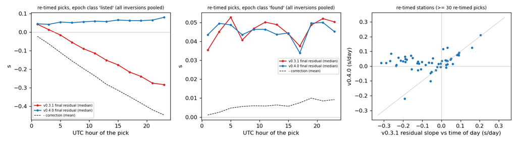

| station | mean_corr_s_v0.3.1 | mean_corr_s_v0.4.0 | mean_res_s_v0.3.1 | mean_res_s_v0.4.0 | n_v0.3.1 | n_v0.4.0 | slope_s_per_day_v0.3.1 | slope_s_per_day_v0.4.0 |
| --- | --- | --- | --- | --- | --- | --- | --- | --- |
| ELK.UW | 0.1932 | 0.1936 | -0.2609 | -0.0893 | 7736 | 7760 | -0.3148 | 0.0211 |
| FL2.UW | 0.1886 | 0.1888 | -0.0744 | 0.0896 | 7668 | 7676 | -0.2883 | 0.0226 |
| TDL.UW | 0.1482 | 0.1486 | -0.1338 | -0.0002 | 6311 | 6307 | -0.1809 | 0.0451 |
| LVP.UW | 0.1535 | 0.1539 | -0.0289 | 0.11 | 6014 | 6017 | -0.2366 | 0.0019 |
| BLN.UW | 0.0891 | 0.0894 | -0.034 | 0.0231 | 5145 | 5139 | -0.1554 | -0.0206 |
| JCW.UW | 0.1074 | 0.1076 | 0.0151 | 0.0592 | 4889 | 4883 | -0.0453 | 0.0545 |
| MTM.UW | 0.161 | 0.1608 | -0.0129 | 0.1194 | 4769 | 4771 | -0.1581 | 0.072 |
| RVW.UW | 0.1842 | 0.184 | -0.2846 | -0.1162 | 4374 | 4382 | -0.2343 | 0.0095 |
| MCW.UW | 0.1128 | 0.1128 | 0.0454 | 0.1092 | 4023 | 4003 | -0.1026 | 0.028 |
| SOS.UW | 0.1465 | 0.1462 | 0.0848 | 0.2096 | 3713 | 3688 | -0.2003 | 0.0324 |
| CDF.UW | 0.1821 | 0.1817 | -0.0338 | 0.1202 | 3438 | 3436 | -0.2623 | 0.0841 |
| SHW.UW | 0.1742 | 0.1728 | -0.0001 | 0.1399 | 3415 | 3393 | -0.2119 | 0.0372 |
| LO2.UW | 0.1233 | 0.1239 | -0.0429 | 0.0355 | 3144 | 3151 | -0.1886 | 0.0296 |
| MBW.UW | 0.1084 | 0.1083 | 0.1822 | 0.2095 | 2861 | 2855 | -0.0831 | 0.008 |
| HSR.UW | 0.1781 | 0.1789 | 0.0018 | 0.1468 | 2765 | 2764 | -0.2674 | 0.0353 |
| EDM.UW | 0.1821 | 0.1764 | 0.2995 | 0.4262 | 2745 | 2634 | -0.2242 | 0.0573 |
| BB510.X9 | -0.0033 | -0.0033 | 0.0133 | 0.0137 | 2472 | 2475 | -0.0025 | -0.0055 |
| LCW.UW | 0.1026 | 0.1027 | -0.1006 | -0.0294 | 2463 | 2466 | -0.1221 | 0.0317 |
| CMW.UW | 0.1447 | 0.1442 | 0.1349 | 0.1981 | 2261 | 2241 | -0.1257 | 0.0207 |
| JUN.UW | 0.1558 | 0.1556 | -0.0845 | 0.0437 | 1969 | 1968 | -0.1893 | 0.0645 |
| HDW.UW | -0.0027 | -0.0027 | 0.0106 | 0.0057 | 1715 | 1716 | 0.0316 | 0.0344 |
| BOW.UW | 0.1526 | 0.1521 | 0.0189 | 0.1151 | 1444 | 1445 | -0.1508 | 0.0551 |
| KMO.UW | 0.1822 | 0.1828 | -0.0463 | 0.0307 | 1417 | 1422 | -0.189 | 0.049 |
| STD.UW | 0.0673 | 0.0683 | 0.0859 | 0.1447 | 1295 | 1294 | -0.1064 | -0.0214 |
| SMW.UW | 0.0711 | 0.0663 | 0.1476 | 0.1773 | 1177 | 1150 | -0.065 | 0.0242 |
| GB380.Z5 | 0.0032 | 0.0032 | -0.075 | -0.0739 | 1059 | 1060 | -0.0288 | -0.0266 |
| BHW.UW | 0.0815 | 0.0819 | -0.1596 | -0.1208 | 870 | 868 | -0.0493 | 0.0212 |
| BB680.Z5 | -0.0048 | -0.0048 | 0.0136 | 0.0162 | 745 | 745 | 0.0465 | 0.0446 |
| BB740.Z5 | -0.0032 | -0.0032 | 0.0104 | 0.0017 | 698 | 698 | 0.0322 | 0.0129 |
| RER.UW | -0.0062 | -0.0062 | 0.2127 | 0.2019 | 694 | 694 | -0.0224 | -0.0055 |
| RVC.UW | -0.0057 | -0.0057 | 0.0672 | 0.0587 | 663 | 663 | -0.0051 | -0.0057 |
| IRO.UO | 0.101 | 0.0997 | -0.0794 | -0.0159 | 623 | 620 | 0.0308 | 0.126 |
| VG2.UW | 0.0952 | 0.0952 | -0.0595 | 0.0007 | 609 | 609 | 0.0094 | 0.1159 |
| SEP.CC | 0.0158 | 0.0155 | 0.38 | 0.4043 | 496 | 495 | 0.0263 | 0.0378 |
| NLO.UW | 0.1549 | 0.1549 | 0.2388 | 0.3174 | 469 | 469 | -0.1173 | 0.0168 |
| KOS.UW | -0.0069 | -0.0069 | 0.0727 | 0.0891 | 408 | 410 | -0.0023 | 0.0182 |
| BB640.Z5 | 0.005 | 0.005 | -0.0147 | -0.012 | 401 | 402 | 0.021 | 0.0407 |
| BRO.UW | 0.1186 | 0.1226 | -0.1504 | -0.0936 | 284 | 290 | 0.0888 | 0.0827 |
| NED.CC | 0.0302 | 0.0298 | 0.4089 | 0.4423 | 278 | 271 | 0.0024 | 0.0347 |
| OBC.UW | 0.0049 | 0.0049 | 0.3035 | 0.2951 | 272 | 269 | -0.056 | -0.0481 |
| CPW.UW | -0.0056 | -0.0056 | 0.2079 | 0.2227 | 267 | 268 | 0.0922 | 0.0919 |
| STW.UW | -0.006 | -0.006 | 0.1229 | 0.1114 | 263 | 263 | 0.0252 | 0.0091 |
| OSD.UW | 0.0035 | 0.0035 | 0.1067 | 0.1075 | 252 | 252 | 0.0901 | 0.0746 |
| GMW.UW | -0.0037 | -0.0037 | -0.155 | -0.1538 | 253 | 251 | -0.0161 | 0.0162 |
| GHW.UW | -0.007 | -0.007 | -0.306 | -0.3144 | 222 | 222 | 0.0501 | 0.0519 |
| BB690.Z5 | -0.0034 | -0.0034 | -0.0022 | 0.0059 | 194 | 193 | 0.0243 | -0.0083 |
| HBO.UW | 0.0291 | 0.0289 | 0.2169 | 0.2393 | 188 | 189 | -0.1228 | -0.0262 |
| RNO.UW | 0.0328 | 0.0324 | 0.1824 | 0.1959 | 185 | 181 | 0.2039 | 0.21 |
| OCP.UW | 0.0028 | 0.0028 | 0.0972 | 0.1002 | 166 | 165 | 0.0584 | 0.015 |
| SUG.CC | 0.0166 | 0.0151 | 0.4396 | 0.4445 | 137 | 134 | -0.1912 | -0.2197 |

## 3. Model differences v0.4.0 - v0.3.1 (merged models)

Resolution masks identical in both models: True. Noise floor = the v0.4.0 chain rerun with N(0, 1e-6 s) added to every observed time (M0 and tiles), merged with the same rules. 'above noise' = |difference| > 2 x the largest |noise difference| among the node and its 26 neighbours.

| quantity | nodes | n | gt1_pct | gt2_pct | rms_pct | max_abs_pct | noise_rms_pct | noise_p99_pct | noise_max_pct | noise_gt1_pct | above_noise_pct | gt1_and_above_noise_pct |
| --- | --- | --- | --- | --- | --- | --- | --- | --- | --- | --- | --- | --- |
| Vp | resolved P (resolution_p > 0) | 888 | 13.06 | 3.27 | 0.838 | 6.06 | 0.7384 | 2.954 | 5.639 | 10.25 | 39.53 | 2.7 |
| Vs | resolved S (resolution_s > 0) | 320 | 8.12 | 2.19 | 0.756 | 8.48 | 0.8154 | 3.191 | 8.876 | 4.38 | 0.94 | 0.62 |
| Vp | tile-covered P (tile_weight_p > 0) | 94656 | 1.75 | 0.5 | 0.339 | 18.48 | 0.1022 | 0.185 | 6.664 | 0.17 | 23.18 | 1.55 |
| Vs | tile-covered S (tile_weight_s > 0) | 94626 | 0.08 | 0.03 | 0.091 | 8.48 | 0.0578 | 0.023 | 8.876 | 0.03 | 21.63 | 0.05 |
| Vp | all nodes | 232932 | 0.71 | 0.2 | 0.216 | 18.48 | 0.0658 | 0.08 | 6.664 | 0.07 | 12.52 | 0.63 |
| Vs | all nodes | 232932 | 0.03 | 0.01 | 0.059 | 8.48 | 0.0376 | 0.021 | 8.876 | 0.01 | 10.54 | 0.02 |
| VpVs | resolved P and S | 255 | 21.18 | 6.67 | 1.084 | 6.77 | 1.084 | 4.492 | 5.496 | 18.82 | 0 | 0 |

| quantity | depth_km | resolved_nodes | gt1_pct | gt2_pct | rms_pct | noise_rms_pct |
| --- | --- | --- | --- | --- | --- | --- |
| Vp | 1 | 20 | 20 | 0 | 0.771 | 0.0123 |
| Vp | 3 | 38 | 15.8 | 0 | 0.681 | 0.0141 |
| Vp | 5 | 51 | 9.8 | 0 | 0.708 | 0.0118 |
| Vp | 7 | 52 | 1.9 | 0 | 0.419 | 0.0097 |
| Vp | 9 | 21 | 0 | 0 | 0.341 | 0.0103 |
| Vp | 12 | 4 | 0 | 0 | 0.19 | 0.0206 |
| Vp | 15 | 256 | 16 | 3.9 | 0.86 | 0.7783 |
| Vp | 18 | 313 | 11.5 | 3.5 | 0.857 | 0.7598 |
| Vp | 29 | 133 | 17.3 | 6 | 1.015 | 1.056 |
| Vs | 7 | 1 | 0 | 0 | 0.048 | 0.1176 |
| Vs | 12 | 1 | 0 | 0 | 0.051 | 0.1073 |
| Vs | 15 | 188 | 4.3 | 2.1 | 0.789 | 0.7814 |
| Vs | 18 | 110 | 13.6 | 1.8 | 0.697 | 0.8608 |
| Vs | 29 | 20 | 15 | 5 | 0.792 | 0.9072 |

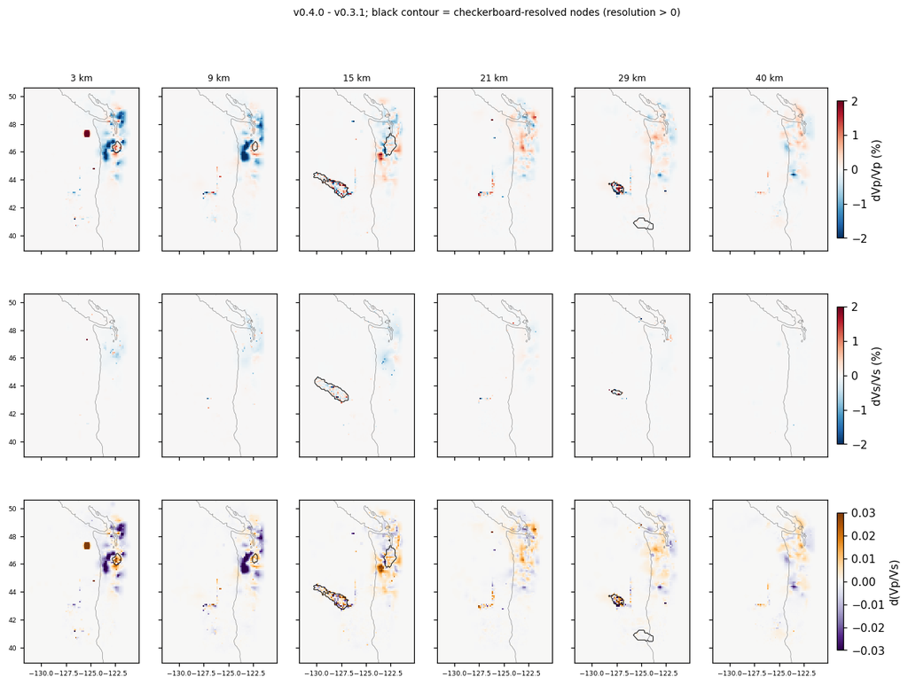

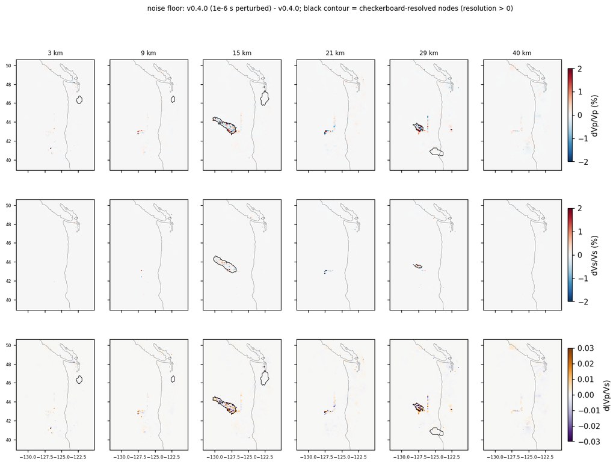

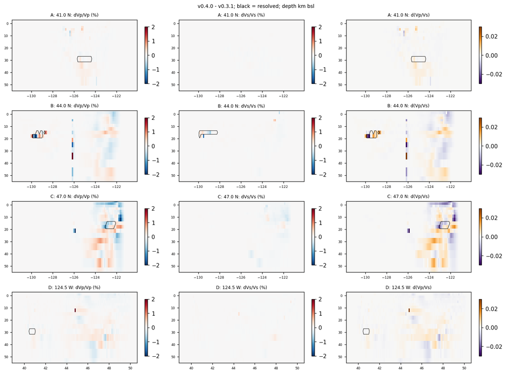

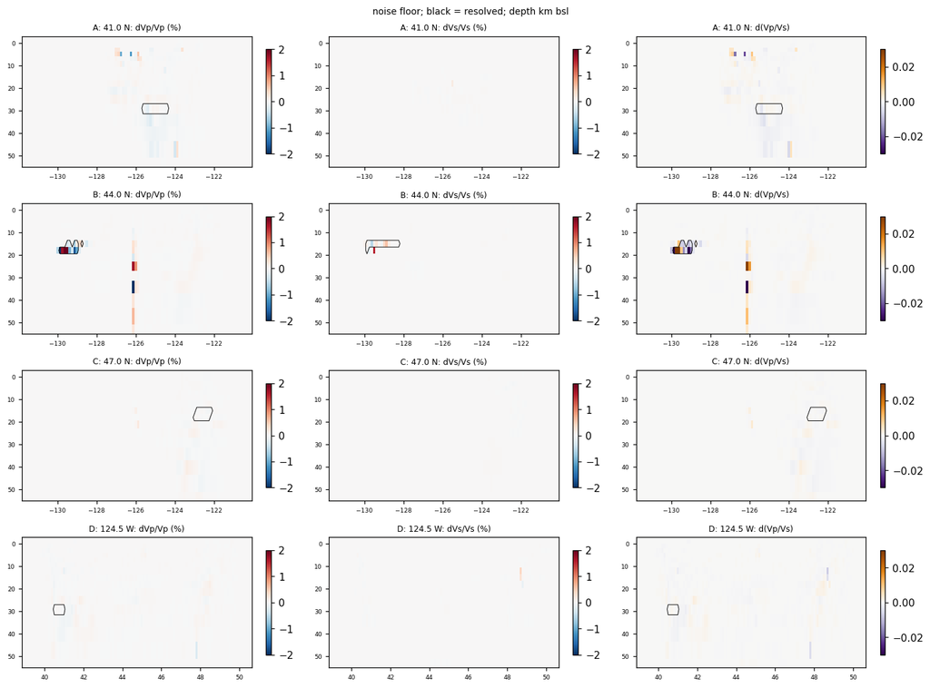

Where resolved nodes moved by more than 1 %:

| quantity | area | zband | nodes | median_pct | max_abs_pct |
| --- | --- | --- | --- | --- | --- |
| Vp | 41-43.5N west of 125.5W | 16-30 km | 31 | -1.072 | 5.782 |
| Vp | 43.5-46N west of 125.5W | 16-30 km | 26 | -0.04066 | 6.057 |
| Vp | 41-43.5N west of 125.5W | 6-16 km | 19 | 1.058 | 2.65 |
| Vp | 43.5-46N west of 125.5W | 6-16 km | 17 | 1.132 | 4.233 |
| Vp | 46-48N east of 123.5W | <6 km | 12 | 1.134 | 1.766 |
| Vp | 46-48N east of 123.5W | 6-16 km | 4 | -1.248 | 1.678 |
| Vp | 43.5-46N east of 123.5W | <6 km | 3 | 1.068 | 1.611 |
| Vp | 43.5-46N east of 123.5W | 6-16 km | 2 | -1.286 | 1.476 |
| Vp | 46-48N east of 123.5W | 16-30 km | 2 | -0.05607 | 1.177 |
| Vs | 41-43.5N west of 125.5W | 16-30 km | 13 | -1.022 | 2.274 |
| Vs | 41-43.5N west of 125.5W | 6-16 km | 5 | 1.054 | 8.478 |
| Vs | 43.5-46N west of 125.5W | 16-30 km | 5 | 1.815 | 2.712 |
| Vs | 43.5-46N west of 125.5W | 6-16 km | 3 | -1.631 | 3.033 |

## 4. Hypocentre shifts of the tomography events (tomoDD final)

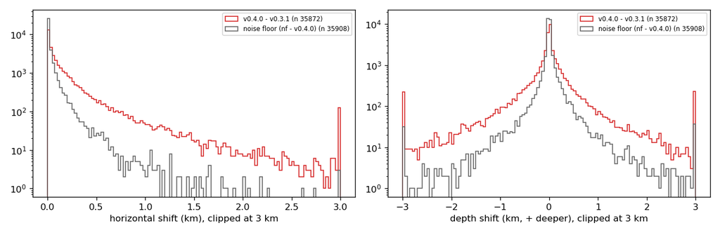

| inversion | comparison | region | events | only_in_one | dh_median_km | dh_p90_km | dz_median_km | dz_absmedian_km | dz_p90abs_km | dt_median_s | gt1km_3d_pct |
| --- | --- | --- | --- | --- | --- | --- | --- | --- | --- | --- | --- |
| M0 | v0.4.0 - v0.3.1 | Axial | 22 |  | 0.016 | 0.053 | -0 | 0.008 | 0.095 | 0 | 0 |
| M0 | v0.4.0 - v0.3.1 | Blanco | 536 |  | 0.022 | 0.099 | 0.002 | 0.038 | 0.242 | 0 | 1.7 |
| M0 | v0.4.0 - v0.3.1 | Cascades | 363 |  | 0.174 | 0.783 | 0.008 | 0.175 | 1.012 | 0 | 17.6 |
| M0 | v0.4.0 - v0.3.1 | Explorer | 211 |  | 0.01 | 0.085 | -0.001 | 0.017 | 0.16 | 0 | 0 |
| M0 | v0.4.0 - v0.3.1 | Gorda | 827 |  | 0.022 | 0.097 | 0.003 | 0.045 | 0.298 | 0 | 2.2 |
| M0 | v0.4.0 - v0.3.1 | JdF ridge/plate | 122 |  | 0.01 | 0.068 | 0 | 0.006 | 0.072 | 0 | 1.6 |
| M0 | v0.4.0 - v0.3.1 | Mendocino | 545 |  | 0.016 | 0.076 | 0.002 | 0.015 | 0.131 | 0 | 0.4 |
| M0 | v0.4.0 - v0.3.1 | Offshore forearc | 1572 |  | 0.026 | 0.137 | 0.001 | 0.035 | 0.271 | 0 | 2.2 |
| M0 | v0.4.0 - v0.3.1 | Other onshore | 1399 |  | 0.062 | 0.418 | 0.001 | 0.082 | 0.837 | 0 | 10 |
| M0 | v0.4.0 - v0.3.1 | Puget/Georgia | 1253 |  | 0.187 | 0.8 | 0.03 | 0.182 | 1.245 | 0 | 18 |
| M0 | v0.4.0 - v0.3.1 | all | 6850 | 11 | 0.043 | 0.353 | 0.002 | 0.058 | 0.603 | 0 | 7.2 |
| M0 | noise floor (nf - v0.4.0) | Axial | 22 |  | 0 | 0.002 | 0 | 0 | 0.002 | 0 | 0 |
| M0 | noise floor (nf - v0.4.0) | Blanco | 536 |  | 0.004 | 0.036 | 0 | 0.007 | 0.084 | 0 | 0.9 |
| M0 | noise floor (nf - v0.4.0) | Cascades | 364 |  | 0.002 | 0.013 | 0 | 0.003 | 0.042 | 0 | 1.1 |
| M0 | noise floor (nf - v0.4.0) | Explorer | 211 |  | 0.011 | 0.068 | 0.001 | 0.012 | 0.168 | 0 | 1.9 |
| M0 | noise floor (nf - v0.4.0) | Gorda | 827 |  | 0.004 | 0.022 | 0 | 0.008 | 0.091 | 0 | 0.8 |
| M0 | noise floor (nf - v0.4.0) | JdF ridge/plate | 122 |  | 0 | 0.002 | 0 | 0 | 0.002 | 0 | 0.8 |
| M0 | noise floor (nf - v0.4.0) | Mendocino | 545 |  | 0.001 | 0.011 | 0 | 0.002 | 0.026 | 0 | 0 |
| M0 | noise floor (nf - v0.4.0) | Offshore forearc | 1572 |  | 0.003 | 0.026 | 0 | 0.005 | 0.056 | 0 | 0.5 |
| M0 | noise floor (nf - v0.4.0) | Other onshore | 1403 |  | 0.002 | 0.017 | 0 | 0.004 | 0.05 | 0 | 0.3 |
| M0 | noise floor (nf - v0.4.0) | Puget/Georgia | 1253 |  | 0.005 | 0.027 | 0 | 0.007 | 0.062 | 0 | 0.2 |
| M0 | noise floor (nf - v0.4.0) | all | 6855 | 0 | 0.003 | 0.024 | 0 | 0.004 | 0.061 | 0 | 0.5 |
| mendocino_gorda_c | v0.4.0 - v0.3.1 | Blanco | 99 |  | 0.03 | 0.098 | -0.017 | 0.088 | 1.153 | 0 | 12.1 |
| mendocino_gorda_c | v0.4.0 - v0.3.1 | Gorda | 2466 |  | 0.023 | 0.11 | -0.009 | 0.054 | 0.334 | 0 | 2.8 |
| mendocino_gorda_c | v0.4.0 - v0.3.1 | Mendocino | 4046 |  | 0.007 | 0.041 | 0.002 | 0.008 | 0.101 | 0 | 1 |
| mendocino_gorda_c | v0.4.0 - v0.3.1 | Offshore forearc | 4281 |  | 0.009 | 0.049 | 0.005 | 0.013 | 0.091 | 0 | 0.9 |
| mendocino_gorda_c | v0.4.0 - v0.3.1 | Other onshore | 1276 |  | 0.008 | 0.037 | 0.003 | 0.01 | 0.1 | 0 | 0.2 |
| mendocino_gorda_c | v0.4.0 - v0.3.1 | all | 12168 | 2 | 0.01 | 0.061 | 0.003 | 0.014 | 0.157 | 0 | 1.4 |
| mendocino_gorda_c | noise floor (nf - v0.4.0) | Blanco | 99 |  | 0.019 | 0.127 | 0.003 | 0.052 | 1.126 | 0 | 12.1 |
| mendocino_gorda_c | noise floor (nf - v0.4.0) | Gorda | 2466 |  | 0.024 | 0.112 | 0.005 | 0.055 | 0.37 | 0 | 3 |
| mendocino_gorda_c | noise floor (nf - v0.4.0) | Mendocino | 4047 |  | 0.006 | 0.04 | -0.001 | 0.007 | 0.093 | 0 | 0.7 |
| mendocino_gorda_c | noise floor (nf - v0.4.0) | Offshore forearc | 4281 |  | 0.009 | 0.048 | -0.005 | 0.013 | 0.091 | 0 | 0.5 |
| mendocino_gorda_c | noise floor (nf - v0.4.0) | Other onshore | 1277 |  | 0.005 | 0.028 | -0.001 | 0.007 | 0.083 | 0 | 0.2 |
| mendocino_gorda_c | noise floor (nf - v0.4.0) | all | 12170 | 0 | 0.01 | 0.06 | -0.002 | 0.013 | 0.156 | 0 | 1.2 |
| blanco | v0.4.0 - v0.3.1 | Blanco | 4211 |  | 0.06 | 0.251 | 0 | 0.092 | 0.602 | 0 | 5.5 |
| blanco | v0.4.0 - v0.3.1 | Gorda | 3 |  | 0.108 | 0.115 | 0.175 | 0.175 | 0.253 | 0 | 0 |
| blanco | v0.4.0 - v0.3.1 | JdF ridge/plate | 73 |  | 0.023 | 0.11 | 0.001 | 0.018 | 0.073 | 0 | 1.4 |
| blanco | v0.4.0 - v0.3.1 | Offshore forearc | 87 |  | 0.204 | 0.554 | 0.041 | 0.21 | 1.218 | 0 | 19.5 |
| blanco | v0.4.0 - v0.3.1 | all | 4374 | 0 | 0.061 | 0.256 | 0 | 0.091 | 0.61 | 0 | 5.7 |
| blanco | noise floor (nf - v0.4.0) | Blanco | 4211 |  | 0.064 | 0.252 | 0.008 | 0.098 | 0.596 | 0 | 5.5 |
| blanco | noise floor (nf - v0.4.0) | Gorda | 3 |  | 0.101 | 0.211 | -0.136 | 0.207 | 0.216 | 0 | 0 |
| blanco | noise floor (nf - v0.4.0) | JdF ridge/plate | 73 |  | 0.036 | 0.13 | 0.006 | 0.02 | 0.129 | 0 | 1.4 |
| blanco | noise floor (nf - v0.4.0) | Offshore forearc | 87 |  | 0.131 | 0.628 | 0.028 | 0.202 | 1.314 | 0.01 | 17.2 |
| blanco | noise floor (nf - v0.4.0) | all | 4374 | 0 | 0.064 | 0.257 | 0.008 | 0.096 | 0.607 | 0 | 5.7 |
| oregon | v0.4.0 - v0.3.1 | Cascades | 970 |  | 0.191 | 0.907 | 0.068 | 0.204 | 0.89 | -0.01 | 16.8 |
| oregon | v0.4.0 - v0.3.1 | Offshore forearc | 465 |  | 0.07 | 0.32 | -0.011 | 0.081 | 0.412 | 0 | 3.2 |
| oregon | v0.4.0 - v0.3.1 | Other onshore | 1879 |  | 0.183 | 0.821 | 0.014 | 0.239 | 1.393 | -0.01 | 20.4 |
| oregon | v0.4.0 - v0.3.1 | all | 3314 | 16 | 0.165 | 0.767 | 0.017 | 0.198 | 1.097 | 0 | 16.9 |
| oregon | noise floor (nf - v0.4.0) | Cascades | 971 |  | 0.002 | 0.025 | 0 | 0.002 | 0.052 | 0 | 0.5 |
| oregon | noise floor (nf - v0.4.0) | Offshore forearc | 465 |  | 0.012 | 0.075 | -0.001 | 0.015 | 0.128 | 0 | 0.9 |
| oregon | noise floor (nf - v0.4.0) | Other onshore | 1888 |  | 0.004 | 0.023 | -0.001 | 0.008 | 0.09 | 0 | 0.3 |
| oregon | noise floor (nf - v0.4.0) | all | 3324 | 1 | 0.004 | 0.031 | -0.001 | 0.006 | 0.082 | 0 | 0.4 |
| washington | v0.4.0 - v0.3.1 | Cascades | 1555 |  | 0.289 | 1.023 | 0.11 | 0.3 | 1.211 | -0.01 | 22.9 |
| washington | v0.4.0 - v0.3.1 | Offshore forearc | 1834 |  | 0.092 | 0.276 | 0.015 | 0.109 | 0.494 | 0 | 4.4 |
| washington | v0.4.0 - v0.3.1 | Other onshore | 1583 |  | 0.214 | 0.955 | -0.022 | 0.265 | 1.428 | -0.01 | 21.4 |
| washington | v0.4.0 - v0.3.1 | Puget/Georgia | 4194 |  | 0.253 | 0.974 | -0.012 | 0.304 | 1.599 | -0.01 | 24.4 |
| washington | v0.4.0 - v0.3.1 | all | 9166 | 42 | 0.21 | 0.864 | 0.012 | 0.245 | 1.296 | -0.01 | 19.6 |
| washington | noise floor (nf - v0.4.0) | Cascades | 1560 |  | 0.004 | 0.018 | -0.001 | 0.004 | 0.043 | 0 | 0.2 |
| washington | noise floor (nf - v0.4.0) | Offshore forearc | 1840 |  | 0.015 | 0.087 | 0.001 | 0.016 | 0.188 | 0 | 1.4 |
| washington | noise floor (nf - v0.4.0) | Other onshore | 1587 |  | 0.004 | 0.029 | 0 | 0.005 | 0.077 | 0 | 0.6 |
| washington | noise floor (nf - v0.4.0) | Puget/Georgia | 4198 |  | 0.013 | 0.06 | 0.003 | 0.019 | 0.131 | 0 | 1.1 |
| washington | noise floor (nf - v0.4.0) | all | 9185 | 11 | 0.009 | 0.052 | 0 | 0.012 | 0.118 | 0 | 0.9 |

## 5. Rule checks (smoothing, D-B046 rule: largest within 1.5 % of the best weighted rms)

| inversion | version | smooth | rms_wt_final | rel_to_best_pct | within_tol | rule_choice | kept_choice |
| --- | --- | --- | --- | --- | --- | --- | --- |
| M0 | v0.3.1 | 20 | 0.201 | 1.31 | True | 480 | 480 |
| M0 | v0.3.1 | 60 | 0.1997 | 0.66 | True | 480 | 480 |
| M0 | v0.3.1 | 120 | 0.1997 | 0.66 | True | 480 | 480 |
| M0 | v0.3.1 | 240 | 0.1984 | 0 | True | 480 | 480 |
| M0 | v0.3.1 | 480 | 0.2012 | 1.41 | True | 480 | 480 |
| M0 | v0.3.1 | 960 | 0.2062 | 3.93 | False | 480 | 480 |
| M0 | v0.3.1 | 1920 | 0.2114 | 6.55 | False | 480 | 480 |
| M0 | v0.4.0 | 20 | 0.1839 | 0.82 | True | 480 | 480 |
| M0 | v0.4.0 | 60 | 0.184 | 0.88 | True | 480 | 480 |
| M0 | v0.4.0 | 120 | 0.1848 | 1.32 | True | 480 | 480 |
| M0 | v0.4.0 | 240 | 0.1824 | 0 | True | 480 | 480 |
| M0 | v0.4.0 | 480 | 0.1844 | 1.1 | True | 480 | 480 |
| M0 | v0.4.0 | 960 | 0.1892 | 3.73 | False | 480 | 480 |
| M0 | v0.4.0 | 1920 | 0.1951 | 6.96 | False | 480 | 480 |
| mendocino_gorda_c | v0.3.1 | 20 | 0.1553 | 2.64 | False | 480 | 480 |
| mendocino_gorda_c | v0.3.1 | 60 | 0.1536 | 1.52 | False | 480 | 480 |
| mendocino_gorda_c | v0.3.1 | 120 | 0.1513 | 0 | True | 480 | 480 |
| mendocino_gorda_c | v0.3.1 | 240 | 0.1519 | 0.4 | True | 480 | 480 |
| mendocino_gorda_c | v0.3.1 | 480 | 0.1535 | 1.45 | True | 480 | 480 |
| mendocino_gorda_c | v0.4.0 | 20 | 0.155 | 1.97 | False | 480 | 480 |
| mendocino_gorda_c | v0.4.0 | 60 | 0.1538 | 1.18 | True | 480 | 480 |
| mendocino_gorda_c | v0.4.0 | 120 | 0.152 | 0 | True | 480 | 480 |
| mendocino_gorda_c | v0.4.0 | 240 | 0.152 | 0 | True | 480 | 480 |
| mendocino_gorda_c | v0.4.0 | 480 | 0.1536 | 1.05 | True | 480 | 480 |
| blanco | v0.3.1 | 20 | 0.1277 | 0 | True | 20 | 20 |
| blanco | v0.3.1 | 60 | 0.1299 | 1.72 | False | 20 | 20 |
| blanco | v0.3.1 | 120 | 0.1313 | 2.82 | False | 20 | 20 |
| blanco | v0.3.1 | 240 | 0.1334 | 4.46 | False | 20 | 20 |
| blanco | v0.3.1 | 480 | 0.1356 | 6.19 | False | 20 | 20 |
| blanco | v0.4.0 | 20 | 0.1284 | 0 | True | 60 | 20 |
| blanco | v0.4.0 | 60 | 0.1301 | 1.32 | True | 60 | 20 |
| blanco | v0.4.0 | 120 | 0.1316 | 2.49 | False | 60 | 20 |
| blanco | v0.4.0 | 240 | 0.1336 | 4.05 | False | 60 | 20 |
| blanco | v0.4.0 | 480 | 0.1355 | 5.53 | False | 60 | 20 |
| oregon | v0.3.1 | 20 | 0.151 | 0 | True | 480 | 480 |
| oregon | v0.3.1 | 60 | 0.1517 | 0.46 | True | 480 | 480 |
| oregon | v0.3.1 | 120 | 0.1516 | 0.4 | True | 480 | 480 |
| oregon | v0.3.1 | 240 | 0.1511 | 0.07 | True | 480 | 480 |
| oregon | v0.3.1 | 480 | 0.1515 | 0.33 | True | 480 | 480 |
| oregon | v0.4.0 | 20 | 0.1195 | 3.46 | False | 480 | 480 |
| oregon | v0.4.0 | 60 | 0.1198 | 3.72 | False | 480 | 480 |
| oregon | v0.4.0 | 120 | 0.1185 | 2.6 | False | 480 | 480 |
| oregon | v0.4.0 | 240 | 0.1161 | 0.52 | True | 480 | 480 |
| oregon | v0.4.0 | 480 | 0.1155 | 0 | True | 480 | 480 |
| washington | v0.3.1 | 20 | 0.1636 | 0.43 | True | 480 | 480 |
| washington | v0.3.1 | 60 | 0.1634 | 0.31 | True | 480 | 480 |
| washington | v0.3.1 | 120 | 0.1629 | 0 | True | 480 | 480 |
| washington | v0.3.1 | 240 | 0.163 | 0.06 | True | 480 | 480 |
| washington | v0.3.1 | 480 | 0.1649 | 1.23 | True | 480 | 480 |
| washington | v0.4.0 | 20 | 0.1331 | 1.84 | False | 480 | 480 |
| washington | v0.4.0 | 60 | 0.1329 | 1.68 | False | 480 | 480 |
| washington | v0.4.0 | 120 | 0.1319 | 0.92 | True | 480 | 480 |
| washington | v0.4.0 | 240 | 0.1307 | 0 | True | 480 | 480 |
| washington | v0.4.0 | 480 | 0.1319 | 0.92 | True | 480 | 480 |

## 6. Inputs, P-4 and resources

```
{
 "M0": {
  "new": "margin_m0_v3",
  "old": "margin_m0_v2",
  "event.dat": "identical",
  "station.dat": "identical",
  "station_codes.csv": "identical",
  "events.csv": "identical",
  "forward.json": "identical",
  "picks_used": {
   "rows": 229308,
   "retimed": 21369,
   "tt_changed": 21327,
   "tt_minus_corr_absmax_s": 0.00010000000000334741,
   "corr_absmax_s": 0.769977,
   "station_corr_absdiff_max_s": 1.0000000119636532e-07
  },
  "absolute.dat": {
   "lines": 229308,
   "changed": 21327,
   "absmax_s": 0.7700000000000031,
   "median_abs_changed_s": 0.08970000000000056
  },
  "dt.ct": {
   "lines": 371263,
   "changed": 37784,
   "absmax_s": 0.7697000000000003,
   "median_abs_changed_s": 0.12959999999999994
  },
  "station_corr": {
   "rows": 1022,
   "rows_old": 1022,
   "unmatched": 0,
   "absdiff_max_s": 0.0,
   "n_diff": 0,
   "identical_file": true
  },
  "MOD": {
   "identical": true,
   "dlnvp_absmax_pct": 0.0,
   "dlnvs_absmax_pct": 0.0
  },
  "problems": []
 },
 "mendocino_gorda_c": {
  "new": "mendocino_gorda_c_m0t",
  "old": "mendocino_gorda_c_m0",
  "event.dat": "identical",
  "station.dat": "identical",
  "station_codes.csv": "identical",
  "events.csv": "identical",
  "forward.json": "identical",
  "picks_used": {
   "rows": 267834,
   "retimed": 908,
   "tt_changed": 904,
   "tt_minus_corr_absmax_s": 9.100000000034688e-05,
   "corr_absmax_s": 0.007964,
   "station_corr_absdiff_max_s": 0.0
  },
  "absolute.dat": {
   "lines": 267834,
   "changed": 904,
   "absmax_s": 0.007900000000001128,
   "median_abs_changed_s": 0.0030999999999998806
  },
  "dt.ct": {
   "lines": 651518,
   "changed": 2224,
   "absmax_s": 0.007900000000001128,
   "median_abs_changed_s": 0.0029000000000003467
  },
  "station_corr": {
   "rows": 318,
   "rows_old": 318,
   "unmatched": 0,
   "absdiff_max_s": 0.0,
   "n_diff": 0,
   "identical_file": true
  },
  "MOD": {
   "identical": false,
   "dlnvp_absmax_pct": 0.18883193957377475,
   "dlnvs_absmax_pct": 0.11083457046302536
  },
  "problems": []
 },
 "blanco": {
  "new": "blanco_m0t",
  "old": "blanco_m0",
  "event.dat": "identical",
  "station.dat": "identical",
  "station_codes.csv": "identical",
  "events.csv": "identical",
  "forward.json": "identical",
  "picks_used": {
   "rows": 85293,
   "retimed": 4130,
   "tt_changed": 4109,
   "tt_minus_corr_absmax_s": 0.0001000000000005853,
   "corr_absmax_s": 0.009519,
   "station_corr_absdiff_max_s": 0.0
  },
  "absolute.dat": {
   "lines": 85293,
   "changed": 4109,
   "absmax_s": 0.009500000000002728,
   "median_abs_changed_s": 0.0036000000000004917
  },
  "dt.ct": {
   "lines": 300516,
   "changed": 12396,
   "absmax_s": 0.009500000000000952,
   "median_abs_changed_s": 0.003400000000000958
  },
  "station_corr": {
   "rows": 171,
   "rows_old": 171,
   "unmatched": 0,
   "absdiff_max_s": 0.0,
   "n_diff": 0,
   "identical_file": true
  },
  "MOD": {
   "identical": false,
   "dlnvp_absmax_pct": 0.16313213703098572,
   "dlnvs_absmax_pct": 0.10951936592690226
  },
  "problems": []
 },
 "oregon": {
  "new": "oregon_m0t",
  "old": "oregon_m0",
  "event.dat": "identical",
  "station.dat": "identical",
  "station_codes.csv": "identical",
  "events.csv": "identical",
  "forward.json": "identical",
  "picks_used": {
   "rows": 122292,
   "retimed": 22115,
   "tt_changed": 22077,
   "tt_minus_corr_absmax_s": 0.00010000000000334741,
   "corr_absmax_s": 0.769977,
   "station_corr_absdiff_max_s": 0.0
  },
  "absolute.dat": {
   "lines": 122292,
   "changed": 22077,
   "absmax_s": 0.7700000000000031,
   "median_abs_changed_s": 0.09980000000000011
  },
  "dt.ct": {
   "lines": 300604,
   "changed": 66462,
   "absmax_s": 0.7697000000000003,
   "median_abs_changed_s": 0.1200000000000001
  },
  "station_corr": {
   "rows": 354,
   "rows_old": 354,
   "unmatched": 0,
   "absdiff_max_s": 0.0,
   "n_diff": 0,
   "identical_file": true
  },
  "MOD": {
   "identical": false,
   "dlnvp_absmax_pct": 8.313425704730049,
   "dlnvs_absmax_pct": 3.059221538325285
  },
  "problems": []
 },
 "washington": {
  "new": "washington_m0t",
  "old": "washington_m0",
  "event.dat": "identical",
  "station.dat": "identical",
  "station_codes.csv": "identical",
  "events.csv": "identical",
  "forward.json": "identical",
  "picks_used": {
   "rows": 334878,
   "retimed": 53116,
   "tt_changed": 53008,
   "tt_minus_corr_absmax_s": 0.00010000000000338731,
   "corr_absmax_s": 0.541288,
   "station_corr_absdiff_max_s": 0.0
  },
  "absolute.dat": {
   "lines": 334878,
   "changed": 53008,
   "absmax_s": 0.5412999999999997,
   "median_abs_changed_s": 0.03920000000000101
  },
  "dt.ct": {
   "lines": 811641,
   "changed": 164023,
   "absmax_s": 0.5412999999999997,
   "median_abs_changed_s": 0.05030000000000001
  },
  "station_corr": {
   "rows": 443,
   "rows_old": 443,
   "unmatched": 0,
   "absdiff_max_s": 0.0,
   "n_diff": 0,
   "identical_file": true
  },
  "MOD": {
   "identical": false,
   "dlnvp_absmax_pct": 8.506745941001604,
   "dlnvs_absmax_pct": 3.582899794404193
  },
  "problems": []
 }
}
```

| run | wall_min | user_min | maxrss_gb |
| --- | --- | --- | --- |
| margin_m0_v3/d200_s120 | 19.1 | 19.1 | 2.44 |
| margin_m0_v3/d200_s1920 | 17.5 | 17.4 | 1.77 |
| margin_m0_v3/d200_s20 | 20.6 | 20.6 | 2.46 |
| margin_m0_v3/d200_s240 | 18.1 | 18 | 1.76 |
| margin_m0_v3/d200_s480 | 18.1 | 18.1 | 1.79 |
| margin_m0_v3/d200_s60 | 19.5 | 19.5 | 2.44 |
| margin_m0_v3/d200_s960 | 17.5 | 17.5 | 2.41 |
| margin_m0_v3nf/d200_s480 | 18.1 | 18.1 | 1.66 |
| blanco_m0t/d200_s120 | 12.4 | 12.4 | 1.37 |
| blanco_m0t/d200_s20 | 12.5 | 12.5 | 1.43 |
| blanco_m0t/d200_s240 | 12.7 | 12.6 | 1.88 |
| blanco_m0t/d200_s480 | 12 | 12 | 1.82 |
| blanco_m0t/d200_s60 | 12.8 | 12.7 | 2.03 |
| blanco_m0tnf/d200_s20 | 13.2 | 13.1 | 1.96 |
| mendocino_gorda_c_m0t/d200_s120 | 42 | 41.8 | 2.78 |
| mendocino_gorda_c_m0t/d200_s20 | 38.3 | 38.1 | 3.14 |
| mendocino_gorda_c_m0t/d200_s240 | 42.1 | 41.8 | 2.91 |
| mendocino_gorda_c_m0t/d200_s480 | 38.1 | 38 | 2.85 |
| mendocino_gorda_c_m0t/d200_s60 | 36.7 | 36.6 | 3.12 |
| mendocino_gorda_c_m0tnf/d200_s480 | 38.1 | 38 | 3.18 |
| oregon_m0t/d200_s120 | 21.7 | 21.6 | 1.9 |
| oregon_m0t/d200_s20 | 21.7 | 21.6 | 1.94 |
| oregon_m0t/d200_s240 | 21.8 | 21.7 | 1.03 |
| oregon_m0t/d200_s480 | 17.8 | 17.7 | 1.15 |
| oregon_m0t/d200_s60 | 21 | 20.9 | 1.92 |
| oregon_m0tnf/d200_s480 | 17.7 | 17.7 | 1 |
| washington_m0t/d200_s120 | 51.3 | 51.1 | 3.56 |
| washington_m0t/d200_s20 | 59.2 | 59 | 3.45 |
| washington_m0t/d200_s240 | 49.8 | 49.6 | 3.6 |
| washington_m0t/d200_s480 | 47 | 46.9 | 3.22 |
| washington_m0t/d200_s60 | 55.4 | 55.2 | 3.29 |
| washington_m0tnf/d200_s480 | 52.4 | 52.1 | 3.54 |
| margin_m0_v3/check01 | 3.1 | 3.1 | 2.11 |
| blanco_m0t/check01 | 2 | 2 | 1.44 |
| mendocino_gorda_c_m0t/check01 | 5.9 | 5.9 | 2.53 |
| oregon_m0t/check01 | 2.4 | 2.4 | 1.55 |
| washington_m0t/check01 | 10.2 | 10.1 | 3.16 |

| job | start | end | seconds |
| --- | --- | --- | --- |
| inp_m0 | 2026-11-25T05:57:13 | 2026-11-25T05:59:59 | 166 |
| inp_m0nf | 2026-11-25T05:57:13 | 2026-11-25T05:59:59 | 166 |
| ver_m0 | 2026-11-25T05:59:59 | 2026-11-25T06:00:14 | 15 |
| chk_m0 | 2026-11-25T06:00:14 | 2026-11-25T06:03:30 | 196 |
| m0_s960 | 2026-11-25T06:03:30 | 2026-11-25T06:21:05 | 1055 |
| m0_s1920 | 2026-11-25T06:03:30 | 2026-11-25T06:21:05 | 1055 |
| m0_s480 | 2026-11-25T06:03:30 | 2026-11-25T06:21:50 | 1100 |
| m0nf_s480 | 2026-11-25T06:03:30 | 2026-11-25T06:21:50 | 1100 |
| m0_s240 | 2026-11-25T06:03:30 | 2026-11-25T06:21:50 | 1100 |
| inp_oregon | 2026-11-25T06:21:50 | 2026-11-25T06:22:05 | 15 |
| inp_blanco | 2026-11-25T06:21:50 | 2026-11-25T06:22:05 | 15 |
| inp_washington | 2026-11-25T06:21:50 | 2026-11-25T06:22:20 | 30 |
| inp_mendocino_gorda_c | 2026-11-25T06:21:50 | 2026-11-25T06:22:20 | 30 |
| ver_oregon | 2026-11-25T06:22:05 | 2026-11-25T06:22:20 | 15 |
| ver_blanco | 2026-11-25T06:22:05 | 2026-11-25T06:22:20 | 15 |
| ver_washington | 2026-11-25T06:22:20 | 2026-11-25T06:22:35 | 15 |
| ver_mendocino_gorda_c | 2026-11-25T06:22:20 | 2026-11-25T06:22:35 | 15 |
| m0_s120 | 2026-11-25T06:03:30 | 2026-11-25T06:22:50 | 1161 |
| inp_washingtonnf | 2026-11-25T06:22:20 | 2026-11-25T06:22:50 | 30 |
| inp_mendocino_gorda_cnf | 2026-11-25T06:22:20 | 2026-11-25T06:22:50 | 30 |
| inp_oregonnf | 2026-11-25T06:22:35 | 2026-11-25T06:22:50 | 15 |
| inp_blanconf | 2026-11-25T06:22:35 | 2026-11-25T06:22:50 | 15 |
| m0_s60 | 2026-11-25T06:03:30 | 2026-11-25T06:23:06 | 1176 |
| m0_s20 | 2026-11-25T06:03:30 | 2026-11-25T06:24:21 | 1251 |
| chk_blanco | 2026-11-25T06:22:20 | 2026-11-25T06:24:21 | 121 |
| chk_oregon | 2026-11-25T06:22:20 | 2026-11-25T06:24:51 | 151 |
| chk_mendocino_gorda_c | 2026-11-25T06:22:35 | 2026-11-25T06:28:37 | 362 |
| chk_washington | 2026-11-25T06:22:35 | 2026-11-25T06:32:53 | 618 |
| scan_blanco_s480 | 2026-11-25T06:24:21 | 2026-11-25T06:36:39 | 739 |
| run_blanco | 2026-11-25T06:24:21 | 2026-11-25T06:36:55 | 754 |
| scan_blanco_s120 | 2026-11-25T06:24:21 | 2026-11-25T06:36:55 | 754 |
| scan_blanco_s60 | 2026-11-25T06:24:21 | 2026-11-25T06:37:10 | 769 |
| scan_blanco_s240 | 2026-11-25T06:24:21 | 2026-11-25T06:37:10 | 769 |
| run_blanconf | 2026-11-25T06:24:21 | 2026-11-25T06:37:40 | 799 |
| run_oregon | 2026-11-25T06:24:51 | 2026-11-25T06:42:41 | 1070 |
| run_oregonnf | 2026-11-25T06:24:51 | 2026-11-25T06:42:41 | 1070 |
| run_mendocino_gorda_c | 2026-11-25T06:28:37 | 2026-11-25T07:06:48 | 2291 |
| run_mendocino_gorda_cnf | 2026-11-25T06:36:55 | 2026-11-25T07:15:05 | 2291 |
| scan_mendocino_gorda_c_s60 | 2026-11-25T06:42:41 | 2026-11-25T07:19:36 | 2215 |
| run_washington | 2026-11-25T06:32:53 | 2026-11-25T07:20:07 | 2833 |
| merge | 2026-11-25T07:20:07 | 2026-11-25T07:20:22 | 15 |
| scan_mendocino_gorda_c_s20 | 2026-11-25T06:42:41 | 2026-11-25T07:21:07 | 2306 |
| scan_washington_s240 | 2026-11-25T06:37:40 | 2026-11-25T07:27:39 | 2999 |
| scan_washington_s120 | 2026-11-25T06:37:10 | 2026-11-25T07:28:39 | 3089 |
| run_washingtonnf | 2026-11-25T06:36:39 | 2026-11-25T07:29:09 | 3150 |
| merge_nf | 2026-11-25T07:29:09 | 2026-11-25T07:29:24 | 15 |
| scan_washington_s60 | 2026-11-25T06:37:10 | 2026-11-25T07:32:40 | 3330 |
| scan_washington_s20 | 2026-11-25T06:36:55 | 2026-11-25T07:36:11 | 3556 |
| scan_oregon_s60 | 2026-11-25T07:20:07 | 2026-11-25T07:41:12 | 1266 |
| scan_oregon_s20 | 2026-11-25T07:19:36 | 2026-11-25T07:41:27 | 1311 |
| scan_oregon_s120 | 2026-11-25T07:21:07 | 2026-11-25T07:42:58 | 1311 |
| scan_mendocino_gorda_c_s120 | 2026-11-25T07:06:48 | 2026-11-25T07:48:59 | 2531 |
| scan_oregon_s240 | 2026-11-25T07:27:39 | 2026-11-25T07:49:45 | 1326 |
| scan_mendocino_gorda_c_s240 | 2026-11-25T07:15:05 | 2026-11-25T07:57:17 | 2531 |
| summaries | 2026-11-25T07:57:17 | 2026-11-25T07:57:32 | 15 |

Merge attributes v0.4.0: {"reference_fallback_fraction_p": 0.1597, "reference_fallback_fraction_s": 0.16, "vs_reverted_nodes": "87960", "vs_capped_nodes": "281", "gated_tiles": "blanco_m0t", "excluded_tiles": "ridges_north", "covered_nodes_p": "112644", "provenance_git_commit": "a94737667325022241d2a74e5e94a2bf29f2f008"}  
v0.3.1: {"reference_fallback_fraction_p": 0.1597, "reference_fallback_fraction_s": 0.16, "vs_reverted_nodes": "87823", "vs_capped_nodes": "258", "gated_tiles": "blanco_m0", "excluded_tiles": "ridges_north", "covered_nodes_p": "112644", "provenance_git_commit": "970f4b51a75efcdfc1f7023a27172d0525ecb2c2"}